# Sparkify Project Workspace

## Evaluating Model

```python
#Show positive and negative label quantity of test set
test_balanced.groupBy('label').count().show()
```

```
VBox()
```

```
FloatProgress(value=0.0, bar_style='info', description='Progress:', layout=Layout(height='25px', width='50%'),…
```

```
+-----+-----+
|label|count|
+-----+-----+
|    1| 1541|
|    0| 1216|
+-----+-----+
```

```python
#Temporary dictionary for making model metrics
temp_dict = {'Logistic': lrModel, "RandomForest": rfcModel, 'Gradient-Boosted Tree': gbtModel}

#Initiate model_metric
model_metrics = {}

#Iterate through models
for model_name in temp_dict.keys():

    #We first evaluate using test_balanced set
    temp_model = temp_dict[model_name].bestModel
    temp_test = temp_model.transform(test_balanced)
    AUC = evaluator.evaluate(temp_test)
    acc, rec, prec, f1 = evaluation(temp_test)
    model_metrics[model_name + "Test"] = [AUC, acc, rec, prec, f1]

    #Then, we also check the whole set
    temp_all = temp_model.transform(ml_data)
    AUC = evaluator.evaluate(temp_all)
    acc, rec, prec, f1 = evaluation(temp_all)
    model_metrics[model_name + "All"] = [AUC, acc, rec, prec, f1]

#Turn result into dataframe
model_metrics_table = pd.DataFrame(model_metrics, index = ['AUC', 'accuracy', 'recall', 'precision', 'f1_score'])
pd.set_option("display.max_rows", None, "display.max_columns", None)
model_metrics_table
```

```
VBox()
```

```
FloatProgress(value=0.0, bar_style='info', description='Progress:', layout=Layout(height='25px', width='50%'),…
```

[output not shown]

```
           LogisticTest  LogisticAll  RandomForestTest  RandomForestAll  \
AUC            0.805422     0.802101          0.843908         0.855079
accuracy       0.744287     0.736152          0.764599         0.781129
recall         0.758598     0.747751          0.757949         0.769338
precision      0.778296     0.447649          0.808864         0.508387
f1_score       0.768321     0.560030          0.782580         0.612216

           Gradient-Boosted TreeTest  Gradient-Boosted TreeAll
AUC                         0.842697                  0.860557
accuracy                    0.760609                  0.777134
recall                      0.770279                  0.781731
precision                   0.795044                  0.502441
f1_score                    0.782465                  0.611715
```

```python
#Backup model_metrics table
model_metrics_table.to_csv('model_metrics.csv')
```

```
VBox()
```

```
FloatProgress(value=0.0, bar_style='info', description='Progress:', layout=Layout(height='25px', width='50%'),…
```

```
VBox()
```

```
FloatProgress(value=0.0, bar_style='info', description='Progress:', layout=Layout(height='25px', width='50%'),…
```

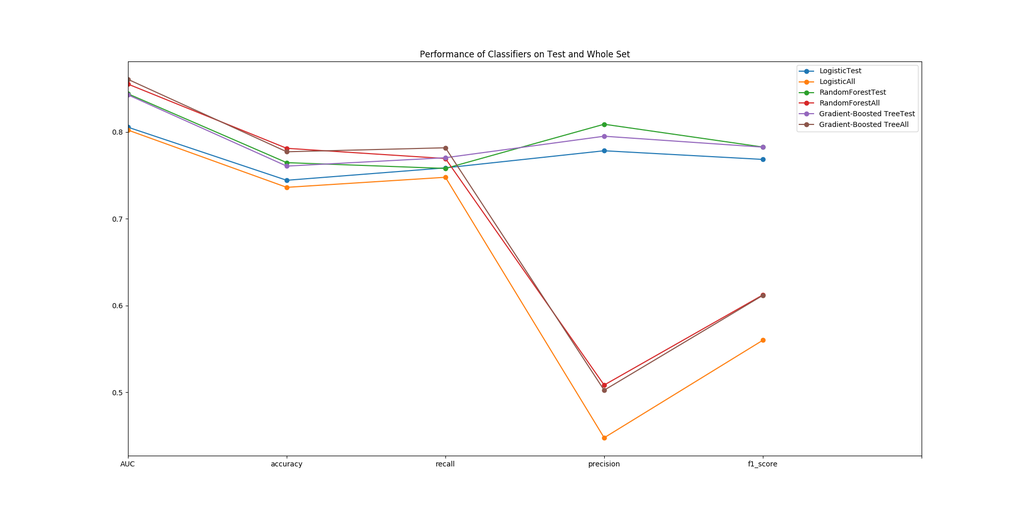

```python
#Plot the result of model_metrics
plt.figure(figsize = [20,10])
model_metrics_table.plot(kind ='line', marker = 'o', figsize = [20,10], xticks = [0,1,2,3,4,5], title = 'Performance of Classifiers on Test and Whole Set')
%matplot plt
```

## Justification

As you see, the performance drop a lot when we analyzed the whole dataset instead of balanced dataset. Because the gradient-boosted tree can easily be overfitted in this small dataset and it's more time-consuming than Random-Forest. We deicide to take Random Forest as our final model.

Overall, Logistic Regression did the worst perhaps because we are analyzing human behavior which is not so linear.

Besides, the psosible possible reasons for gradient-boosted tree to get overfitted so easily is that the algorithm is iterative and greedy, as we only have little amount of data, it's easy to get overfitted.

The major problem causing overall failure in whole set in my opinion is due to dataset size, because the amount of data is not enough to represent population, the model could easily get biased.

### Logistic Regression-Coefficient

In this part, we analyzed the contribution of features by coefficient

```
VBox()
```

```
FloatProgress(value=0.0, bar_style='info', description='Progress:', layout=Layout(height='25px', width='50%'),…
```

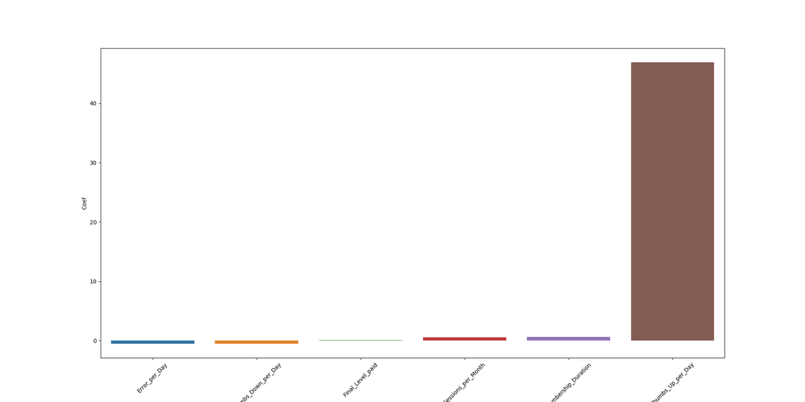

```python
#Retrieve coefficient information from LR Model
LR_Coef = lrModel.bestModel.coefficients
LR_Coef_Table = pd.DataFrame({"Features": feature_columns, "Coef":LR_Coef})
LR_Coef_Table.sort_index(by = 'Coef', inplace = True)
plt.figure(figsize = [20,10])
sb.barplot(x = 'Features', y = 'Coef', data = LR_Coef_Table)
plt.xticks(rotation = 45)
%matplot plt
```

### RandomForest Importance

In this part, we analyzed the contribution of features by importance

```
VBox()
```

```
FloatProgress(value=0.0, bar_style='info', description='Progress:', layout=Layout(height='25px', width='50%'),…
```

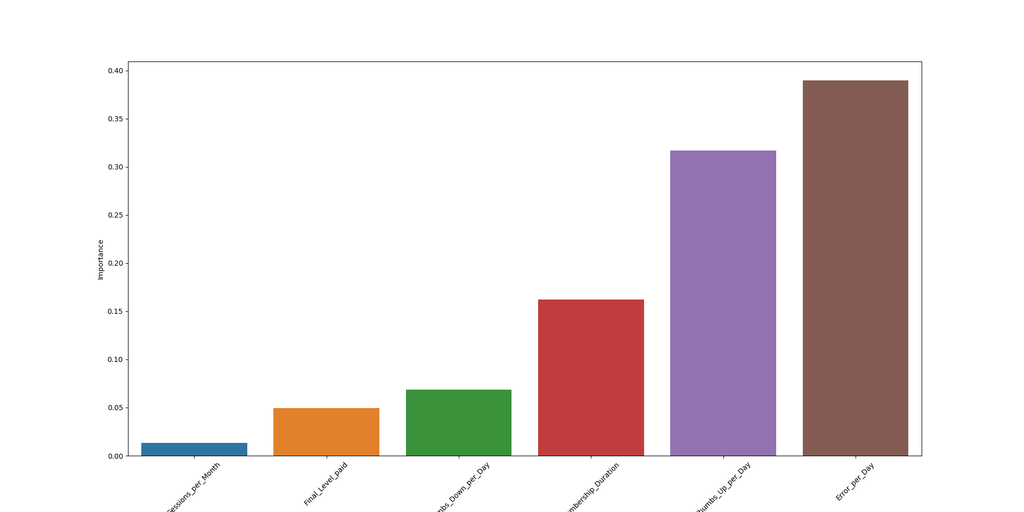

```python
#Retrive feature importance from Random Forest model
RFC_Importance = rfcModel.bestModel.featureImportances
RFC_Importance_Table = pd.DataFrame({"Features": feature_columns, "Importance":RFC_Importance})
RFC_Importance_Table.sort_index(by = 'Importance', inplace = True)
plt.figure(figsize = [20,10])
sb.barplot(x = 'Features', y = 'Importance', data = RFC_Importance_Table)
plt.xticks(rotation = 45)
%matplot plt
```

### Gradient-Boosted Tree Importance

In this part, we analyzed the contribution of features by importance

```
VBox()
```

```
FloatProgress(value=0.0, bar_style='info', description='Progress:', layout=Layout(height='25px', width='50%'),…
```

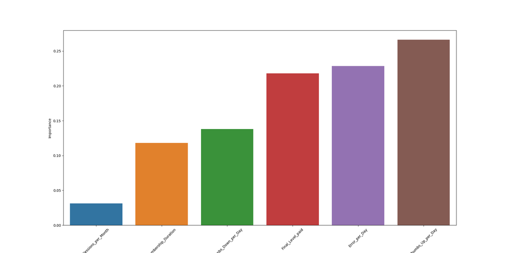

```python
#Retrive feature importance from Gradient-Boosted Tree model
GBT_Importance = gbtModel.bestModel.featureImportances
GBT_Importance_Table = pd.DataFrame({"Features": feature_columns, "Importance":GBT_Importance})
GBT_Importance_Table.sort_index(by = 'Importance', inplace = True)
plt.figure(figsize = [20,10])
sb.barplot(x = 'Features', y = 'Importance', data = GBT_Importance_Table)
plt.xticks(rotation = 45)
%matplot plt
```

## Conclusion

### Reflection

- We have done tons of exploratory data analysis and found that actually most analysis does not reflect obvious difference between churned and non churned user group
- With proper exploratory analysis, we finally chose some features that seems to be significant enough to separate churne and non churned users. Thankfully, this works but not so well and can be further improved.
- At the beginning of machine process, we first do preliminary test to decide desirable positive to negative lable ratio to try to enhance to ability of classification because if we don't do it, the classifier may not be able to properly predict (or can even lead to one class prediction)
- We start from three candidates-Logistic Regression, Random Forest and Graduent-Boosted Tree. The performance of Logistic regression is slightly worse than the other two. When testing using balanced test set, we can obtain accuracy close to 75% and f1 also close to 0.75. However, the performance drops a lot after testing with whole dataset.
- Random Forest and Gradient-Boosted Tree's performance are quite similar, but it's more likely for Gradient-Boosted Tree to overfit and it's more time-consuming. We decide that Random Forest may be the better choice of final model in this project.
- It seems it's pretty hard to further improve the model with this small dataset, we should later work on the full dataset that can really interpret general user behavior
- From feature importance analysis, we can sayt that ratings and errors are pretty important for service provider. It's crucial for service provider to make sure their service are steady and please users that they are willing to give out positive ratings instead of negative ones.

## Improvement

Blog Post of this project can be found here https://burgercewu.medium.com/never-lose-any-one-sparkify-user-churn-prediction-challenge-using-pyspark-7ab67ac080d4 Github Repository can be found here https://github.com/BurgerWu/Sparkify-Project